# Habitat Demo Instructions

Ernesto Carrella

October 1, 2015

## Rocky Areas Get Fished First

Very simple definition of habitat: how much of the substrata is rocky versus how much is sandy. We can make it far more complicated later, but this will do for now. There are two subsystems that interact with habitat:

1. Fishing Gear: the gear effectivness (catchability) can depend on the habitat
2. Biology: the capacity of a sea patch can be a function of the habitat

The basic idea was to see what happens forcing fishers to use gear that works only in one habitat.  
So imagine that there is one big rocky rectangle somewhere in the middle of the sea. The biology is such that the carrying capacity is much higher in the rocky area than it is outside of it.

[figure not shown]

Now if the gear given to the fisher is as effective in rocky areas as it is in sandy ones, the fishers discover very quickly that rocky areas are more bountiful and consume those first.

[figure not shown]

Consuming the whole biomass before moving to sandy areas:

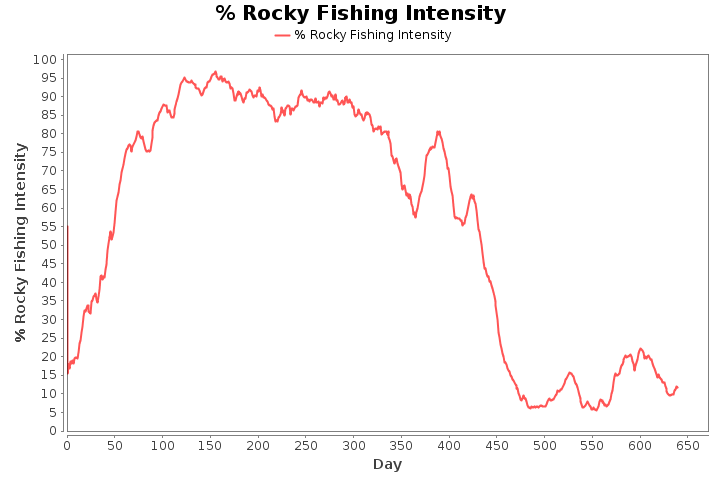

## If fishing in rocky areas is impossible, fishing the rocky line emerges

Now imagine that we give fishers gear that only work in sandy areas (catchability in rocky areas is 0).  
Functionally that’s like an habitat wide MPA and the results are very similar. Fishers who try to fish in rocky areas catch nothing, learning very quickly to stay away.  
The result is two-fold, initially fishers simply ignore the area for sandy spots that are profitable.

[figure not shown]

While you can already spot some fishers staying at the edge of the rocky area, the result is far stronger when most of the sandy areas are consumed:

[figure not shown]

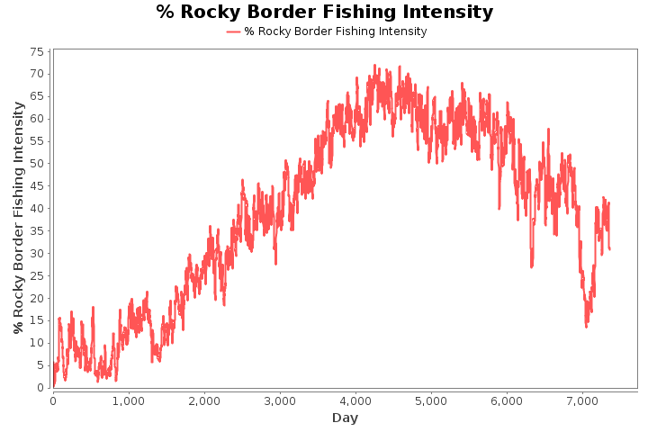

## Choose Your Own Adventure.

For this demo I distributed the executable file so everybody can start running their own simulations and test my results. The initial screen has a few parameters you can tweak:

[figure not shown]

Basically you have the habitat parameters (each cell is a logistic box, with capacity and steepness), the fishing gear parameters (catchability values per soil type) and habitat values (is it all sandy or are there rocky rectangles and if so how big are they).  
Once you are okay with the values the model starts and looks like this:

[video not shown]

In the policy section you can change the gear of all the fishers or their regulations and so on.  
I’d like you to give it a try and tell me what you think, how it feels and what you’d like to see. Both in terms of models and just usability and colors.